# CSC 444 Data Visualization

Final Exam Review

December 6, 2022

# 1 Viz critique

You need to apply Munzner’s What-Why-How Framework: map to data-task-idiom trio to evaluate the quality of the visualization:

- What? (data, data quality)
- Why? (user intent)
- How? (visual encoding – scales, perceptual issues, interaction)

Remember also the general guidelines:

- Maximize data-to-ink ratio
- Avoid multiple font faces, and extraneous colors and backgrounds
- Simplify, mute, or delete gridlines
- Remove superfluous axis marks and labels
- Avoid excessive decorative embellishments

## 1.1 Visualization A

[figure not shown]

*Visualization by Stephan Teodosescu (@steodosescu)*

*Overall the visualizations are good at showing changes of number of flights over time for countries in Europe. However, it’s not clear what the colors mean (encoding). Also, counting departing AND arriving flights together obscures information – showing departing and arriving flights would be more meaningful (why). The changes in line get confusing the lower ranked the country – the colors don’t help here either (encoding).*

## 1.2 Visualization B

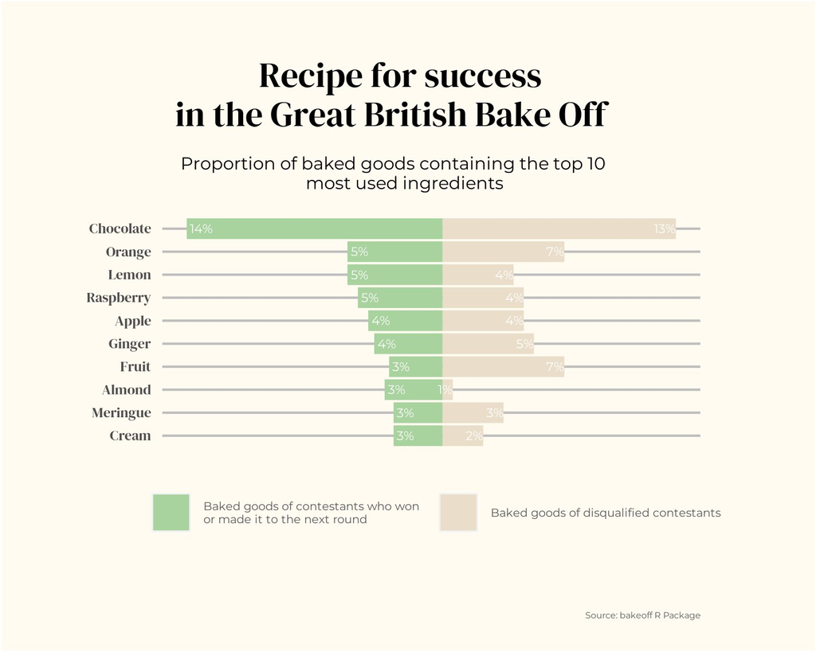

*Visualization by Pauline Baudry @PauBaudry*

*All bars sum to 100%, instead of splitting the comparison won vs. disqualified, which makes comparisons difficult (why). Especially since these are not all the ingredients used, but only the top 10 (data/encoding). The light color is very similar to the background, and the white font makes it very hard to read (encoding).*

## 1.3 Visualization C

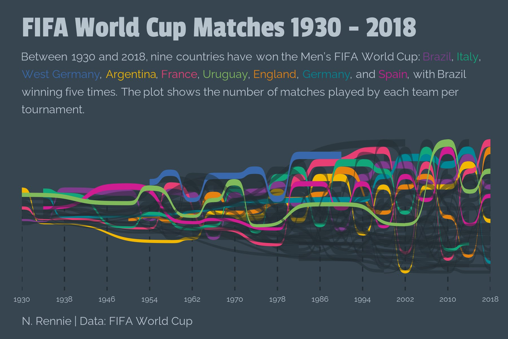

*Visualization by Nicola Rennie @nrennie35*

*Number of matches played might not be the ideal to understand the countries that perform better (why) so it’s not clear what the point is here. The plot is hard to read, too many lines overlapping (encoding). Maybe a comparison between number of matches played for winners would be more informative (why).*

## 1.4 Visualization D

[figure not shown]

*Visualization by Dan Oehm @danoehm*

*Not everyone will recognize the flag for the countries, making it interactive with the country name showing up would add to the accessibility of the plot. Nice interpretation of results in the text at the top (why), but I am not sure the interpretation has any actual meaning. The home vs. away is not meaningful here (data), it is just the way the data is organized. The more I try to understand this plot, the harder it gets.*

# 2 Variable mapping to viz encodings

Variables can be:

- Quantitative/numeric
  - Discrete: counts like number of bigfoot sightings
  - Continuous: temperature, height
- Categorical:
  - Ordered: size
  - Unordered: countries

Color schemes that best represent each type of variable:

- Gradients/Sequential with single hue for continuous numeric variables from low to high to represent numeric continuous/ordered variables (e.g., population size). Light colors should represent low values, and dark colors high values.

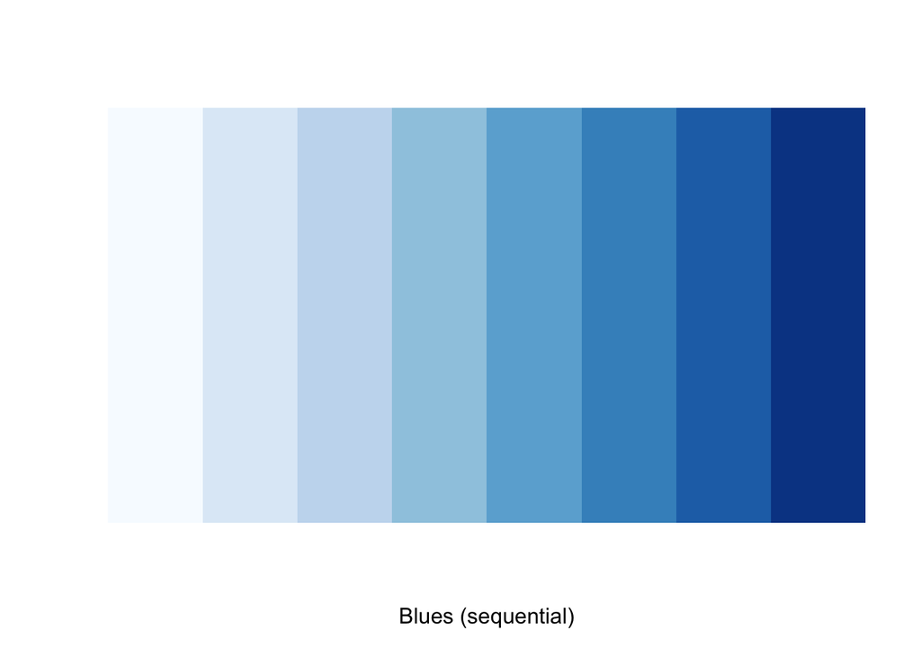

- Diverging scales should be used where there is a neutral midpoint and then there is variance in ether direction from that neutral point (e.g., temperatures can be positive and negative).

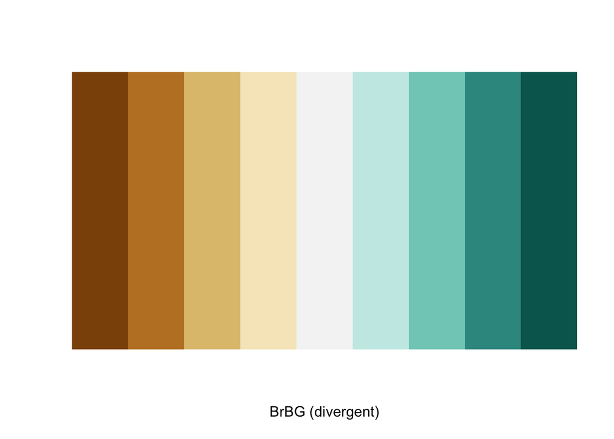

- Qualitative palettes where each color has the same valence (i.e., no color dominates the other) should be used for unordered categorical variables (e.g., political parties, countries). Different colors in the palette should not imply differences in magnitude.

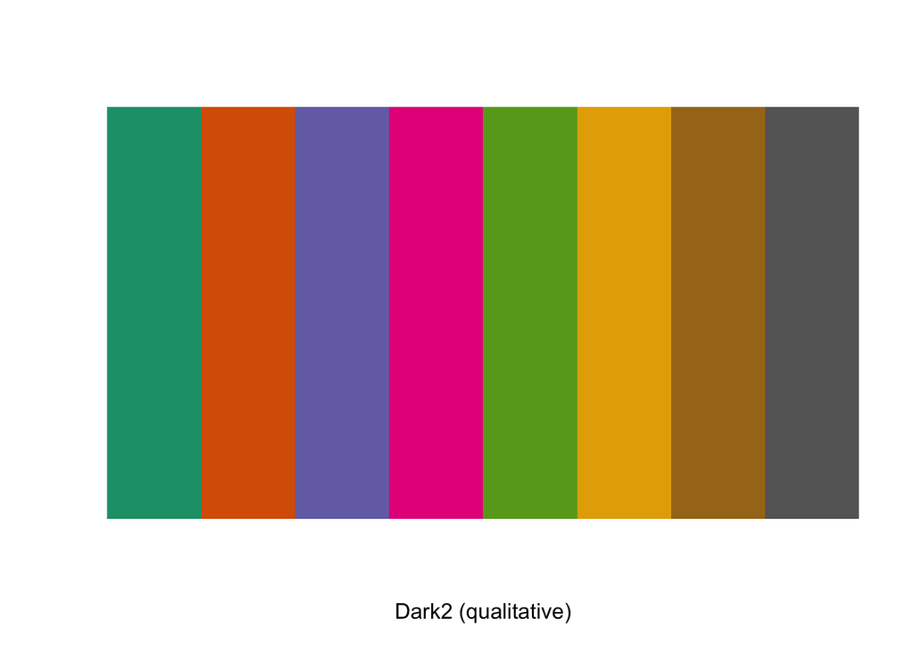

## 2.1 What variable types are present in the following data:

| year | state | id | total | DEMOCRAT | REPUBLICAN | democrat_difference | republican_difference |
| --- | --- | --- | --- | --- | --- | --- | --- |
| 2020 | ALABAMA | 1 | 2323282 | 0.3656999 | 0.6203164 | -0.2546165 | 0.2546165 |
| 2020 | ALASKA | 2 | 359530 | 0.4277195 | 0.5283314 | -0.1006119 | 0.1006119 |
| 2020 | ARIZONA | 4 | 3387326 | 0.4936469 | 0.4905598 | 0.0030871 | -0.0030871 |
| 2020 | ARKANSAS | 5 | 1219069 | 0.3477506 | 0.6239573 | -0.2762067 | 0.2762067 |
| 2020 | CALIFORNIA | 6 | 17500881 | 0.6348395 | 0.3432072 | 0.2916322 | -0.2916322 |
| 2020 | COLORADO | 8 | 3279980 | 0.5501107 | 0.4160413 | 0.1340694 | -0.1340694 |
| 2020 | CONNECTICUT | 9 | 1823857 | 0.5926073 | 0.3918712 | 0.2007361 | -0.2007361 |
| 2020 | DELAWARE | 10 | 504346 | 0.5874301 | 0.3977488 | 0.1896813 | -0.1896813 |
| 2020 | DISTRICT OF COLUMBIA | 11 | 344356 | 0.9214969 | 0.0539732 | 0.8675237 | -0.8675237 |
| 2020 | FLORIDA | 12 | 11067456 | 0.4786145 | 0.5121982 | -0.0335837 | 0.0335837 |

* *Categorical unordered: state, id* * *Categorical/discrete ordered: year* * *Numeric discrete: total* * *Numeric continuous: DEMOCRAT, REPUBLICAN, democrat_difference (divergent), republican_difference (divergent)*

### 2.1.1 What variables would you map to build the following visualizations based on these data:

1. A line plot showing the percentage of votes to the democratic candidate across the years for the state of Arizona *x to year, y to DEMOCRAT, optionally: split by state with interactive element, so state mapped to color/interaction*
2. A map plot with percent democrat/republican votes per state *democrat_difference mapped to fill for each shape*
3. A bar plot showing the 5 states that voted the most republican and the 5 states that voted the most democrat *fill to democrat/republican, state mapped to y (so that we can read labels horizontally), total votes mapped to x, optional interactive element mapping to year*

### 2.1.2 What color scheme would use for each of the visualizations above?

1. *Qualitative color scheme for state* 1. *Divergent color scale, with red representing more republican and blue more democratic – make zero white* 1. *Red bars for republican votes, Blue for democratic votes. No need to map color to state since state is mapped to one of the axes.*

## 2.2 What variable types are present in the following data (NYTimes best sellers):

| id | title | author | year | total_weeks | first_week | debut_rank | best_rank |
| --- | --- | --- | --- | --- | --- | --- | --- |
| 0 | “H” IS FOR HOMICIDE | Sue Grafton | 1991 | 15 | 1991-05-05 | 1 | 2 |
| 1 | “I” IS FOR INNOCENT | Sue Grafton | 1992 | 11 | 1992-04-26 | 14 | 2 |
| 10 | ‘’G’’ IS FOR GUMSHOE | Sue Grafton | 1990 | 6 | 1990-05-06 | 4 | 8 |
| 100 | A DOG’S JOURNEY | W. Bruce Cameron | 2012 | 1 | 2012-05-27 | 3 | 14 |
| 1000 | CHANGING FACES | Kimberla Lawson Roby | 2006 | 1 | 2006-02-19 | 11 | 14 |
| 1001 | CHAOS | Patricia Cornwell | 2016 | 3 | 2016-12-04 | 1 | 7 |
| 1002 | CHAPTERHOUSE: DUNE | Frank Herbert | 1985 | 16 | 1985-04-21 | 9 | 2 |
| 1003 | CHARADE | Sandra Brown | 1994 | 5 | 1994-05-01 | 7 | 10 |
| 1004 | CHARLESTON | John Jakes | 2002 | 4 | 2002-08-25 | 7 | 12 |
| 1005 | CHARLOTTE GRAY | Sebastian Faulks | 1999 | 1 | 1999-03-14 | 12 | 17 |

* *Categorical unordered: author, title, id* * *Categorical/discrete ordered: year, firt_week* * *Numeric discrete: total_weeks, debut_rank, best_rank*

### 2.2.1 What visualization would you built to answer the following questions? Include which variables you would map to each encoding, and what color scheme you would use:

1. What are the top 10 books that stayed the most weeks in the NYTimes best sellers list? *bar plot mapping title to y axis, and total number of weeks to x*
2. How has the debut ranking for books by Stephen King changed over time? *line plot with year mapped to x, and debut_rank mapped to y* 1.1 How does debut rank for Stephen King compare with debut rank by Danielle Steel over time? **line plot with year mapped to x, debut_rank mapped to y, qualitative fill color mapped to author*
3. Which books had the largest difference between best rank and debut rank? *line plot with debut rank vs. best rank labels (categories for rank type) mapped to x, and actual rank number for debut_rank and best_rank mapped to y, two colors: one for positive change, another color for negative change. Annotate plot with title of the book (or make it show up when hovering over the line)*

# 3 Vega spec completion

Complete the Vega specification for the three plots (they all use the same data – NY Times Best Sellers).

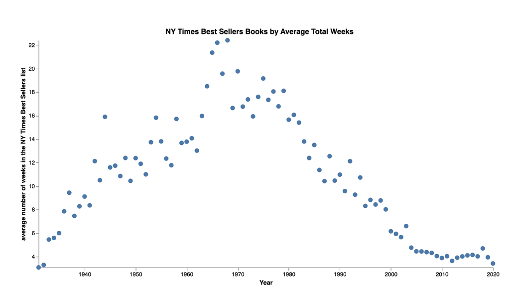

```javascript
var spec = {
  $schema: "https://vega.github.io/schema/vega/v5.json",
  description: "NY Times Best Sellers of All Times",
  width: 800,
  height: 400,
  padding: 50,
  data: [
    {
      name: "books",
      url: "https://raw.githubusercontent.com/rfordatascience/tidytuesday/master/data/2022/2022-05-10/nyt_titles.tsv",
      format: { type: "tsv" }
    },
    {
      name: "aggregate",
      source: "books",
      transform: [
        {
          type: "aggregate",
          groupby: ["year"],
          fields: ["total_weeks"],
          ops: ["mean"],
          as: ["total_weeks"]
        }
      ]
    }
  ],
  scales: [
    {
      name: "xScale",
      type: "linear",
      domain: { field: "year", data: "aggregate" },
      range: "width",
      zero: false
    },
    {
      name: "yScale",
      type: "linear",
      domain: { field: "total_weeks", data: "aggregate" },
      range: "height",
      zero: false
    }
  ],
  axes: [
    {
      scale: "xScale",
      orient: "bottom",
      format: "d",
      title: "Year"

    },
    {
      scale: "yScale",
      orient: "left",
      title: "average number of weeks in the NY Times Best Sellers list"
    }
  ],
  marks: [
    {
      type: "symbol",
      from: { data: "aggregate" },
      encode: {
        enter: {
          x: { field: "year", scale: "xScale" },
          y: { field: "total_weeks", scale: "yScale" },
        }
      }
    }
  ],
  title: {
    text: "NY Times Best Sellers Books by Average Total Weeks"
  }
};
```

[figure not shown]

```javascript
var spec = {
  $schema: "https://vega.github.io/schema/vega/v5.json",
  description: "NY Times Best Sellers of All Times",
  width: 800,
  height: 800,
  padding: 50,
  data: [
    {
      name: "books",
      url: "https://raw.githubusercontent.com/rfordatascience/tidytuesday/master/data/2022/2022-05-10/nyt_titles.tsv",
      format: { type: "tsv" },
      transform: [
        {
          type: "formula",
          expr: "datum.total_weeks / 1",
          as: "total_weeks"
        },
        {
          type: "collect",
          sort: { field: "total_weeks", order: "descending"}
        },
        {
          type: "filter",
          expr: "datum.total_weeks > 94"
        }
      ]
    }
  ],
  scales: [
    {
      name: "yScale",
      type: "linear",
      domain: [2020, 1931],
      range: "height",
      zero: false
    },
    {
      name: "xScale",
      type: "linear",
      domain: { field: "total_weeks", data: "books" },
      range: "width"
    }
  ],
  axes: [
    {
      scale: "xScale",
      orient: "bottom",
      title: "total weeks in the NY Times Best Sellers list"
    },
    {
      scale: "yScale",
      orient: "left",
      format: "d",
      title: "Year"

    }
  ],
  marks: [
    {
      type: "rect",
      from: { data: "books" },
      encode: {
        enter: {
          y: { field: "year", scale: "yScale" },
          x: { field: "total_weeks", scale: "xScale" },
          x2: { value: 0, scale: "xScale" },
          height: { value: 3 }
        }
      }
    },
    {
      type: "text",
      from: {data : "books" },
      encode: {
        enter: {
          text: { signal: "datum.title + ' by ' + datum.author + ' ' + datum.year" },
          y: { field: "year", scale: "yScale" },
          x: { field: "total_weeks", scale: "xScale" },
          align: { value: "right"}
        }
      }
    }
  ],
  title: {
    text: "NY Times Best Sellers Books with longest total weeks in list",
    subtitle: "The 1980s didn't have any books in the list for more than 94 weeks"
  }
};
```

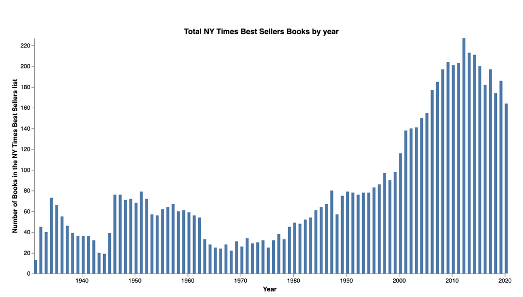

```javascript
var spec = {
  $schema: "https://vega.github.io/schema/vega/v5.json",
  description: "NY Times Best Sellers of All Times",
  width: 800,
  height: 400,
  padding: 50,
  data: [
    {
      name: "books",
      url: "https://raw.githubusercontent.com/rfordatascience/tidytuesday/master/data/2022/2022-05-10/nyt_titles.tsv",
      format: { type: "tsv" }
    },
    {
      name: "aggregate",
      source: "books",
      transform: [
        {
          type: "aggregate",
          groupby: ["year"]
        }
      ]
    }
  ],
  scales: [
    {
      name: "xScale",
      type: "linear",
      domain: { field: "year", data: "aggregate" },
      range: "width",
      zero: false
    },
    {
      name: "yScale",
      type: "linear",
      domain: { field: "count", data: "aggregate" },
      range: "height",
      zero: true
    }
  ],
  axes: [
    {
      scale: "xScale",
      orient: "bottom",
      title: "Year",
      format: "d"

    },
    {
      scale: "yScale",
      orient: "left",
      title: "Number of Books in the NY Times Best Sellers list"
    }
  ],
  marks: [
    {
      type: "rect",
      from: { data: "aggregate" },
      encode: {
        enter: {
          x: { field: "year", scale: "xScale" },
          y: { field: "count", scale: "yScale" },
          y2: { value: 0, scale: "yScale" },
          width: { value: 5 }
        }
      }
    }
  ],
  title: {
    text: "Total NY Times Best Sellers Books by year"
  }
};
```

# 4 Audiences, purposes, and storytelling

Consider the three plots from the previous questions when answering the following questions:

## 4.2 What is the big idea?

*The 1970s and 1980s were not great for the book industry (not a lot of popular books in the NY Times Best Sellers list). There has been an abundance of books in the list since the 2000s, with a number of books staying in the list well over 100 weeks total. It is not clear if this is an indication that people are reading more, but it is an indication that more books are being published.*

## 4.3 What would the audience be for this story?

*Bookstores that want to make informed decisions on what to stock their shelves with.*